# Facts about Usage of LME in Livestock Breeding

## Disclaimer

Facts important for usage of LME in livestock breeding are presented

## Background

Parents do not pass phenotypes to their offspring but just a random sample of their alleles. This can be seen by the following scheme

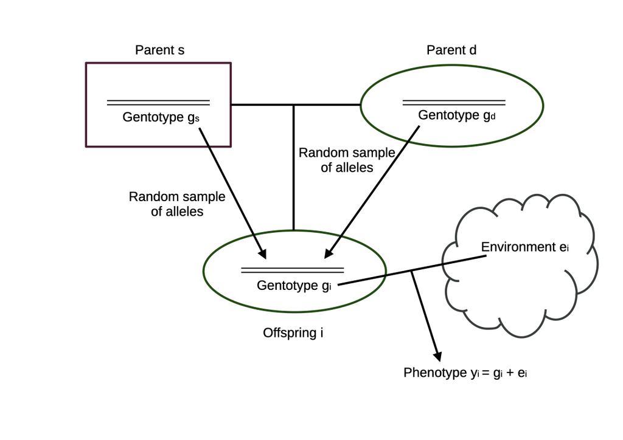

As a consequence it is not efficient to select animals as parents based on their phenotypic record. What we need is a measure for the random sample of alleles that are passed from parents to offspring. This measure is called the `breeding value` and is often termed by the variable $u$. As such, the breeding value $u_i$ of animal $i$ cannot be observed. The above figure shows the relationship between the phenotype $y_i$ of animal $i$ and its breeding value $u_i$. Since, the breeding value $u_i$ cannot be observed or measured, we try to predict it based on phenotypic observations $y_i$.

## Prediction of Breeding Values

Let us assume for a moment that breeding values can be observed or measured for a group of animals. Furthermore each of these animals also has a phenotypic observation. Then the breeding values $u_i$ and the phenotypic observations $y_i$ can be plotted in a coordinate system where the breeding values are shown on the ordinate. For a given number of animals this might look as follows

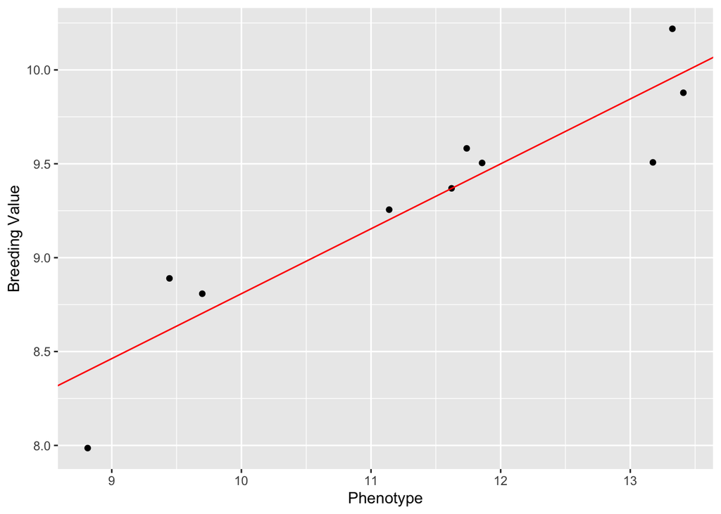

```r
set.seed(1205)
n_mu_u <- 9.3
n_sd_u <- 1.7
n_mu_y <- 12.4
n_h2 <- 0.36
n_sd_y <- n_sd_u / sqrt(n_h2)
n_nr_ani <- 10
vec_y <- rnorm(n_nr_ani, mean = n_mu_y, sd = n_sd_y)
vec_u <- n_h2 * vec_y + rnorm(n_nr_ani, sd = 0.2)
vec_u <- vec_u - mean(vec_u) + n_mu_u
tbl_data <- tibble::tibble(`Breeding Value` = vec_u,
                           Phenotype = vec_y)
lm_bv_phen <- lm(`Breeding Value` ~ Phenotype, data = tbl_data)
# plot
library(ggplot2)
ggplot(data = tbl_data,
       mapping = aes(x = Phenotype,
                     y = `Breeding Value`)) +
  geom_point() +
  geom_abline(slope = lm_bv_phen$coefficients[["Phenotype"]],
              intercept = lm_bv_phen$coefficients[["(Intercept)"]],
              colour = "red")
```

For a new animal $i$ with a phenotypic observation $y_i$, the breeding value can be predicted using the regression line. From that we get

$$\widehat{u_i} = \mu_u + b * (y_i -
\mu_y)$$

with $\mu_u$, the mean or the expected value of $u$, similarly for $\mu_y$. The regression coefficient $b$ is computed as

$$b = \frac{cov(u,y)}{var(y)}$$

Looking at this prediction process from the point of view of distributions and assuming that $y$ and $u$ are normally distributed, then the above regression equation corresponds to the conditional expectation of $u$ given $y$ interpreted as a function of $y$. Hence

$$\widehat{u_i} = E(u_i | y_i) = E(u_i) +
\frac{cov(u_i, y_i)}{var(y_i)} * (y_i - E(y_i))$$

## Generalisation

The above developed prediction process can be generalized. Given that we have the linear mixed effects model for a vector $y$ of length $n$ with observations, we can write

$$y = Xb + Zu + e$$

with vectors

- $b$ of length $p$ containing fixed effects,
- $u$ of length $q$ with random breeding values and
- $e$ of length $n$ with random residuals.

In the above model, there are two vectors with random effects, hence this model is a linear mixed effects model. The expected values and the variance-covariance matrices of the random components can be specified as

$$E\left[\begin{array}{c} y \\ u \\ e \end{array} \right] =
\left[\begin{array}{c} Xb \\ 0 \\ 0 \end{array} \right]$$

$$var\left[\begin{array}{c} y \\ u \\ e \end{array} \right] =
\left[\begin{array}{ccc} V &
ZU & R\\ UZ^T & U & 0\\
R & 0 & R\end{array} \right]$$

with

- $R = I * \sigma_e^2$
- $U = A * \sigma_u^2$, where $A$ is a genetic relationship matrix
- $V = ZUZ^T + R$

The prediction of the breeding values in vector $u$, is also based on the conditional mean $E(u | y)$. This can be written as shown above

$$\widehat{u} = E(u | y) = E(u) + cov(u,
y^T) \cdot var(y)^{-1} \cdot (y - E(y))$$

Inserting the above made specification, we obtain

$$\widehat{u} = UZ^T \cdot V^{-1} \cdot (y
- Xb)$$

Because $b$ is not known, it is replaced by the BLUE estimate $\widehat{b}$ which is given by

$$\widehat{b} = (X^TV^{-1}X)^- X^TV^{-1}y$$

## Properties of Estimates

The following properties of the estimates can be shown

### Fixed Effects

With

$$\widehat{b} = (X^TV^{-1}X)^- X^TV^{-1}y$$

- The expected value is obtained by

$$E((X^TV^{-1}X)\widehat{b}) =
E((X^TV^{-1}X)(X^TV^{-1}X)^- X^TV^{-1}y) = X(X^TV^{-1}X)^- X^TV^{-1}
\cdot E(y) = (X^TV^{-1}X)(X^TV^{-1}X)^- X^TV^{-1}Xb =
(X^TV^{-1}X)b$$
Hence, estimable functions are **unbiased**.

- The variance of the estimater is

$$var(\widehat{b}) = var((X^TV^{-1}X)^-
X^TV^{-1}y) = (X^TV^{-1}X)^- X^TV^{-1} var(y) V^{-1} X (X^TV^{-1}X)^- =
(X^TV^{-1}X)^- X^T V^{-1} X (X^TV^{-1}X)^-
= (X^TV^{-1}X)^-$$

Alternative estimator

$$\widehat{b}^* = \widehat{b} +
\epsilon$$

### Random Effects

- unbiased
- minimum predicetion error variances

## Solution via Mixed Model Equations